# Empowered, Yet Shrinking: How Women’s Economic Gains Are Rewriting the Demographics of Prosperity

Authors: Nikita Jain and Kelsang Tsomo

Date: 2025-11-24

[interactive chart not shown]

# A Quiet Crisis Born from Progress

Across the developed world, prosperity has taken on a paradoxical edge. In cities from Seoul to Stockholm, the same forces that have lifted women’s economic agency are quietly reshaping population structures. Fertility rates have fallen to historic lows, and what once symbolized social progress: rising education, greater workforce participation, and expanded autonomy now intersects with a demographic downturn no country has yet reversed. Between 2015 and 2023, fertility declined across every income tier but nowhere more dramatically than among the world’s richest countries. High-income economies now average around 1.5 births per woman, well below the replacement level of 2.1, while low-income countries remain above 4.5 as shown in Figure 1. The linear trends reveal an unmistakable downward slope, showing that prosperity itself has become the best predictor of demographic contraction. This transformation reflects not simply cultural change but a re-ordering of how modern societies balance opportunity, work, and family. As Kabeer (2012) notes, women’s empowerment, which represents the capacity to access resources and make autonomous life decisions, is inseparable from economic development. Yet empowerment, when unsupported by institutional mechanisms like childcare and flexible work, can make family formation harder. Our decade-long lens captures the aftermath of the post-recession recovery and the pre-COVID digital boom, where women’s opportunities expanded faster than institutions adapted to them. This tension between empowerment and structure sets the stage for the inequalities that follow.

[interactive chart not shown]

# The Unequal Geography of Decline

By 2023, fertility patterns revealed an unmistakable gradient (Figure 2): the richer the country, the fewer the births. The bar chart’s distribution confirms that high-income nations cluster below replacement, while low-income economies remain demographically vibrant. This split represents not only divergent lifestyles but diverging futures, aging labor forces on one end, expanding youth populations on the other. This divergence reflects what Upadhyay et al. (2014) term the **empowerment–fertility paradox**: as women gain greater control over education, income, and family planning, fertility tends to decline. Yet the paradox lies not in empowerment itself, but because institutions fail to adapt. Without affordable childcare, shared parental leave, or career re-entry programs, women face what Kabeer (2012) calls the **double burden**: the expectation to excel at work while carrying the majority of domestic responsibilities. Where policies lag, progress becomes self-limiting. Countries like Japan and South Korea exemplify this disconnect. Their fertility rates, 1.3 and 0.72 respectively, reflect societies where women are more educated and employed than ever before but where long work hours and rigid career norms make motherhood professionally costly. These nations demonstrate that empowerment, when isolated from supportive policy, does not necessarily translate into sustainable family life. At the other end of the spectrum, lower-middle-income nations, averaging 3.31 births per woman, remain in earlier stages of demographic transition. As more women there enter the labor force and gain financial independence, the patterns we now see in richer countries are likely to repeat unless institutional infrastructures evolve alongside empowerment. This realization naturally questions how empowerment, in its different dimensions interacts with fertility outcomes across nations.

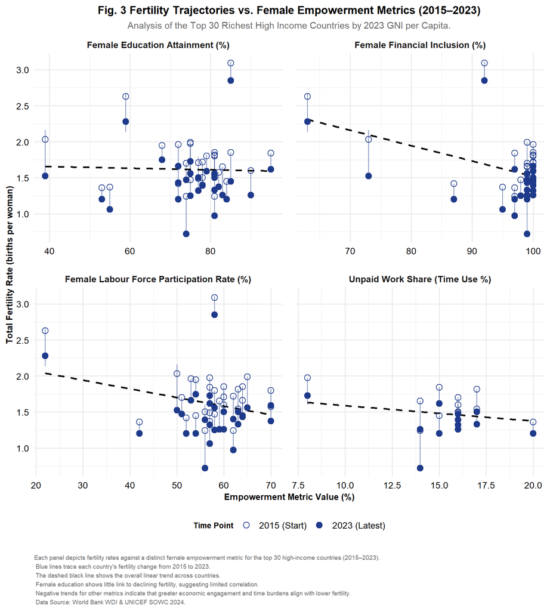

# Empowerment’s Blind Spot: What Missing Data Reveals

The relationship between women’s empowerment and fertility becomes more complex when we examine the data behind it. Across the world’s 30 wealthiest nations, rising education, labor participation, unpaid domestic work and financial inclusion, consistent patterns emerge. Education, long considered the cornerstone of empowerment, shows a surprisingly weak link to declining fertility. High levels of female educational attainment coexist with fertility rates ranging between 1.0 and 2.0 births per woman, suggesting that once education is near universal, its marginal effect on fertility stabilizes. In contrast, economic empowerment metrics, particularly financial inclusion and labor force participation exhibit stronger negative relationships with fertility. Countries with greater female financial independence and full-time employment tend to show sharper fertility declines between 2015 and 2023. Yet the most revealing signal came from unpaid work. In countries where women shoulder a higher share of domestic and caregiving duties, fertility remained persistently low despite prosperity. This suggests that empowerment’s benefits in the labor market can be offset by **time poverty** at home (women have so much unpaid household and caregiving work that they lack the discretionary time needed to balance employment and family, limiting their ability to have more children), a dynamic invisible in most economic data. Here lies a methodological limitation we encountered directly. Even in high-income contexts, official datasets fail to capture unpaid care labor comprehensively. Time-use statistics are incomplete, and “financial inclusion” is inconsistently defined across sources. Our scatter analysis therefore approximates empowerment through measurable proxies, acknowledging that qualitative dimensions , cultural norms, workplace flexibility, or family expectations remain unquantified. This limitation underscores the need for a critical stance toward our own data. As Upadhyay et al. (2014) argue, the absence of information about care work is itself evidence of inequality: what societies neglect to measure, they often undervalue. While our analysis captures strong macro-patterns, it cannot isolate causation, empowerment and fertility move together, but the direction of influence may vary across contexts. Recognizing these blind spots, we turned to another dimension, the design of parental support systems to test whether institutional structures could counterbalance these demographic pressures.

[figure not shown]

# Policy Promises and Contradictions

Comparing parental leave and maternal support across wealthy nations revealed an intricate paradox of policy and practice. Some countries prioritize cash benefits for all mothers, others employment-based paid leave for working parents. For women navigating modern labor markets, the difference determines whether motherhood feels like a temporary adjustment or a permanent setback.

The United States, for example, reports zero weeks of paid federal maternity leave. Japan and South Korea offer paid leave within formal employment but provide little to women outside it. Nordic nations like Sweden, Finland, and Norway, often cited as models, appear moderate in raw data but in fact provide extensive gender-neutral shared leave. Sweden’s 300 shared days and Norway’s combined 343 reflect a shift toward egalitarian caregiving.

Yet even with these policies, fertility continues to fall, Sweden’s rate reached 1.45 in 2023 (Macrotrends, 2025). This contradiction reveals the limits of policy alone. As living costs rise and social norms delay childbearing, even progressive welfare states struggle to sustain fertility. The correlation between empowerment and low fertility therefore cannot be offset by cash transfers or leave duration alone; it hinges on deeper cultural and economic reforms.

Still, this policy lens clarified an important alternative explanation: where gender equality policies focus on fairness at work but not flexibility in life, empowerment can improve equity yet worsen demographic imbalance.

[interactive chart not shown]

# Aging into Imbalance

The demographic outcome of these forces is visible in the numbers (Figure 5). Between 2015 and 2023, the thirty richest countries faced simultaneous fertility collapse and aging acceleration. Our analysis shows that nations with the steepest fertility declines also registered the fastest growth in old-age dependency ratios — the number of older adults per 100 working-age people. South Korea stands out: fertility dropped by 0.52, while the dependency ratio surged by 8.26 points, the largest among peers. Japan, already aging rapidly, reached 50.3 elderly per 100 workers, with fertility falling another 0.25. Similar trajectories appear in Finland, Canada, and Singapore. Multiple factors intersect here. OECD (2024) data confirm that women across advanced economies are delaying childbirth as higher education and dual-career norms become the default. The **motherhood penalty** (Correll et al., 2007) compounds this pattern: mothers face wage losses, promotion gaps, and reduced re-entry prospects, while fathers often receive wage premiums. Our findings echo this imbalance where gender equality is achieved only within the workplace, demographic equality falters outside it. Gulf states such as Saudi Arabia still sustain larger families through traditional norms and immigration, but as female education and employment expand, similar demographic transitions are likely. The mathematics of aging remain unforgiving: when births decline and lifespans extend, the demographic balance tilts irreversibly toward dependency unless societies adapt both economically and culturally. We also recognize the methodological limits of our temporal window. The 2015–2023 period captures post-recession and pandemic-era dynamics but cannot fully reflect long-term policy lag effects. Future analysis could extend to pre-2000 data or incorporate micro-level household surveys to strengthen causal inference.

# Redesigning Prosperity for the Next Generation

Our findings trace a complex but consistent story: women’s empowerment and fertility are intertwined through structures that have not evolved at the same pace. Economic equality has advanced faster than social adaptation, producing a paradox where autonomy expands even as family formation declines. Addressing this does not mean reversing empowerment; it means completing it. Countries must reconceive prosperity around care, not competition, valuing the unpaid labor that sustains both economies and families. Incorporating care work into national accounts, as Kabeer (2012) proposes, would render women’s invisible contributions measurable and actionable. Universal childcare and flexible work arrangements could relieve time constraints shown in our unpaid-work data, while inclusive parental leave that extends to informal and self-employed workers would bridge the gaps evident in our policy comparison. Economic incentives should accompany cultural ones, normalizing paternal caregiving and reducing the motherhood penalty that deters childbearing. Ultimately, empowerment’s success should be judged not only by women’s access to opportunity but by society’s capacity to make that opportunity compatible with sustainability. The demographic future of prosperity depends on whether nations can turn empowerment from an individual achievement into a collective equilibrium, one where equality and continuity thrive together.

# Sources (APA 7th Edition)

Correll, Shelley J., Benard, S., & Paik, I. (2007). Getting a Job: Is There a Motherhood Penalty? American Journal of Sociology, 112(5), 1297–1339. https://doi.org/10.1086/511799

Kabeer, N. (2012). Women’s economic empowerment and inclusive growth: labour markets and enterprise development. https://www.womenindisplacement.org/sites/g/files/tmzbdl1471/files/2020-10/Womens%20Economic%20Empowerment%20and%20Inclusive%20Growth.pdf

Macrotrends. (2025). Sweden Fertility Rate | Historical Data | Chart | 1950-2025. Macrotrends.net. https://www.macrotrends.net/datasets/global-metrics/countries/swe/sweden/fertility-rate

Mammen, K., & Paxson, C. (2000). Women’s Work and Economic Development. The Journal of Economic Perspectives, 14(4), 141–164. https://www.jstor.org/stable/2647079

OECD. (2024). OECD Family Database - OECD. Www.oecd.org. https://www.oecd.org/els/family/database.htm

Upadhyay, U. D., Gipson, J. D., Withers, M., Lewis, S., Ciaraldi, E. J., Fraser, A., Huchko, M. J., & Prata, N. (2014). Women’s empowerment and fertility: A review of the literature. Social Science & Medicine, 115, 111–120. https://doi.org/10.1016/j.socscimed.2014.06.014

World Bank Open Data. (2024). World Bank Open Data. https://data.worldbank.org/indicator/SP.DYN.TFRT.IN?locations=S